# Métodos de Análisis de Datos 1

Unidad 0: Introducción al Análisis de Datos - Práctica

Universidad Nacional del Sur

# Guía de Instalación y Configuración

Esta sección te guiará en la instalación de las herramientas necesarias para el curso.

## 1. Instalación de Visual Studio Code

**Visual Studio Code** (VS Code) es el editor que usaremos durante todo el curso.

### Pasos:

1. **Descargar VS Code:**
   - Ir a: https://code.visualstudio.com/
   - Descargar la versión para tu sistema operativo (Windows, macOS, Linux)
2. **Instalar:**
   - Ejecutar el instalador descargado
   - En Windows: marcar la opción “Add to PATH” durante la instalación
   - Seguir las instrucciones del instalador
3. **Verificar instalación:**
   - Abrir VS Code
   - Debería aparecer la pantalla de bienvenida

## 2. Instalación de Python con Anaconda

**Anaconda** es una distribución de Python que incluye las librerías científicas más importantes.

### Pasos:

1. **Descargar Anaconda:**
   - Ir a: https://www.anaconda.com/products/distribution
   - Descargar la versión más reciente (Python 3.11 o superior)
2. **Instalar:**
   - Ejecutar el instalador
   - **Importante en Windows:** Marcar “Add Anaconda to my PATH environment variable” (aunque diga que no es recomendado)
   - Completar la instalación
3. **Verificar instalación:**
   - Abrir una terminal/command prompt
   - Ejecutar: `python --version`
   - Debería mostrar algo como: `Python 3.11.x`
   - Ejecutar: `conda --version`
   - Debería mostrar la versión de conda

### Librerías incluidas en Anaconda:

- `numpy`: Computación numérica
- `pandas`: Manipulación de datos
- `matplotlib`: Visualizaciones básicas
- `seaborn`: Visualizaciones estadísticas
- `scikit-learn`: Machine learning
- `jupyter`: Notebooks interactivos

## 3. Instalación de R y RStudio

### Instalar R:

1. **Descargar R:**
   - Ir a: https://cran.r-project.org/
   - Seleccionar tu sistema operativo
   - Descargar e instalar la versión más reciente (R 4.3 o superior)
2. **Verificar instalación:**
   - Abrir R desde el menú de inicio
   - En la consola, ejecutar: `version`
   - Debería mostrar la versión de R instalada

### Instalar RStudio:

1. **Descargar RStudio Desktop:**
   - Ir a: https://posit.co/download/rstudio-desktop/
   - Descargar la versión gratuita
   - Instalar
2. **Verificar instalación:**
   - Abrir RStudio
   - Debería abrir con la interfaz de 4 paneles

### Instalar paquetes necesarios:

```r
# Instalar tidyverse (colección de paquetes para análisis de datos)
install.packages("tidyverse")

# Instalar otros paquetes útiles
install.packages(c(
  "caret",          # Machine learning
  "rpart",          # Árboles de decisión
  "rpart.plot",     # Visualización de árboles
  "corrplot",       # Visualización de correlaciones
  "GGally",         # Extensión de ggplot2
  "knitr",          # Reportes
  "rmarkdown"       # R Markdown
))

# Verificar instalación
library(tidyverse)
print("¡Paquetes instalados correctamente!")
```

## 4. Configuración de VS Code para R

### Instalar la extensión de R:

1. **Abrir VS Code**
2. **Ir a Extensions** (`Ctrl+Shift+X`)
3. **Buscar:** “R”
4. **Instalar:** R (de REditorSupport)

### Instalar el paquete languageserver en R:

Esto habilita autocompletado y ayuda en VS Code.

```r
install.packages("languageserver")
```

### Configurar el path de R en VS Code:

1. En VS Code: `Ctrl+,` (abrir configuración)
2. Buscar: “r.rpath”
3. Configurar la ruta donde está instalado R:
   - Windows: `C:/Program Files/R/R-4.3.x/bin/R.exe`
   - macOS: `/usr/local/bin/R`
   - Linux: `/usr/bin/R`

### Trabajar con archivos R en VS Code:

1. **Crear archivo:** `test.R`
2. **Escribir:** `print("Hola R")`
3. **Ejecutar:**
   - Seleccionar la línea
   - `Ctrl+Enter` (envía el código a la terminal de R)

### Trabajar con R Markdown en VS Code:

1. **Crear archivo:** `test.Rmd`
2. VS Code puede previsualizar y ejecutar chunks de código
3. Para renderizar a HTML/PDF:

```r
rmarkdown::render("test.Rmd")
```

## 5. Usar Python desde VS Code

Aunque este notebook es de R, también necesitarás trabajar con Python.

### Configurar Python en VS Code:

1. **Instalar extensiones:**
   - Python (de Microsoft)
   - Jupyter (de Microsoft)
2. **Verificar:**
   - Crear archivo: `test.py`
   - Escribir: `print("Hola Python")`
   - Click derecho → “Run Python File in Terminal”

## 6. Git y GitHub

### Instalar Git:

1. **Descargar Git:**
   - Ir a: https://git-scm.com/
   - Descargar para tu sistema operativo
   - Instalar (dejar opciones por defecto)
2. **Configurar Git:**
   - Abrir terminal en VS Code (`Ctrl+``)
   - Ejecutar:

   ```bash
   git config --global user.name "Tu Nombre"
   git config --global user.email "tu@email.com"
   ```

3. **Verificar:**

   ```bash
   git --version
   ```

### Crear cuenta en GitHub:

1. Ir a: https://github.com/
2. Click en “Sign up”
3. Completar el formulario de registro
4. Verificar email

### Crear tu primer repositorio:

1. **En GitHub:**
   - Click en “+” (esquina superior derecha)
   - “New repository”
   - Nombre: `metodos-analisis-datos-1`
   - Descripción: “Prácticas del curso MAD1 - UNS 2026”
   - Marcar “Add a README file”
   - Click “Create repository”
2. **Clonar a tu máquina:**
   - Copiar la URL del repositorio (botón verde “Code”)
   - En VS Code: `Ctrl+Shift+P` → “Git: Clone”
   - Pegar la URL
   - Elegir carpeta donde guardar

# Práctica: Caso de Estudio con el Dataset Iris

Ahora que tenemos todo configurado, vamos a hacer un análisis completo del dataset Iris siguiendo el ciclo de análisis de datos.

## Paso 1: Obtención de Datos

El dataset Iris está incluido en R, así que lo cargamos directamente.

```r
# Cargar librerías necesarias
library(tidyverse)    # Para manipulación y visualización
library(caret)        # Para machine learning
library(rpart)        # Para árboles de decisión
library(rpart.plot)   # Para visualizar árboles
library(corrplot)     # Para visualizar correlaciones
library(GGally)       # Para pair plots

# Fijar semilla para reproducibilidad
set.seed(42)

cat("Librerías cargadas correctamente\n")
```

```
Librerías cargadas correctamente
```

```r
# Cargar dataset Iris (viene incluido en R)
data(iris)

# Convertir a tibble (formato tidyverse)
iris_df <- as_tibble(iris)

cat("Dataset cargado exitosamente\n")
```

```
Dataset cargado exitosamente
```

```r
cat("Dimensiones:", nrow(iris_df), "filas x", ncol(iris_df), "columnas\n")
```

```
Dimensiones: 150 filas x 5 columnas
```

## Paso 2: Exploración Inicial

```r
# Ver las primeras filas
cat("Primeras 6 filas del dataset:\n")
```

```
Primeras 6 filas del dataset:
```

```r
head(iris_df)
```

| Sepal.Length | Sepal.Width | Petal.Length | Petal.Width | Species |
| --- | --- | --- | --- | --- |
| 5.1 | 3.5 | 1.4 | 0.2 | setosa |
| 4.9 | 3.0 | 1.4 | 0.2 | setosa |
| 4.7 | 3.2 | 1.3 | 0.2 | setosa |
| 4.6 | 3.1 | 1.5 | 0.2 | setosa |
| 5.0 | 3.6 | 1.4 | 0.2 | setosa |
| 5.4 | 3.9 | 1.7 | 0.4 | setosa |

```r
# Estructura del dataset
cat("\nEstructura del dataset:\n")
```

```
Estructura del dataset:
```

```r
str(iris_df)
```

```
tibble [150 × 5] (S3: tbl_df/tbl/data.frame)
 $ Sepal.Length: num [1:150] 5.1 4.9 4.7 4.6 5 5.4 4.6 5 4.4 4.9 ...
 $ Sepal.Width : num [1:150] 3.5 3 3.2 3.1 3.6 3.9 3.4 3.4 2.9 3.1 ...
 $ Petal.Length: num [1:150] 1.4 1.4 1.3 1.5 1.4 1.7 1.4 1.5 1.4 1.5 ...
 $ Petal.Width : num [1:150] 0.2 0.2 0.2 0.2 0.2 0.4 0.3 0.2 0.2 0.1 ...
 $ Species     : Factor w/ 3 levels "setosa","versicolor",..: 1 1 1 1 1 1 1 1 1 1 ...
```

```r
# Estadísticas descriptivas
cat("\nEstadísticas descriptivas:\n")
```

```
Estadísticas descriptivas:
```

```r
summary(iris_df)
```

```
  Sepal.Length    Sepal.Width     Petal.Length    Petal.Width
 Min.   :4.300   Min.   :2.000   Min.   :1.000   Min.   :0.100
 1st Qu.:5.100   1st Qu.:2.800   1st Qu.:1.600   1st Qu.:0.300
 Median :5.800   Median :3.000   Median :4.350   Median :1.300
 Mean   :5.843   Mean   :3.057   Mean   :3.758   Mean   :1.199
 3rd Qu.:6.400   3rd Qu.:3.300   3rd Qu.:5.100   3rd Qu.:1.800
 Max.   :7.900   Max.   :4.400   Max.   :6.900   Max.   :2.500
       Species
 setosa    :50
 versicolor:50
 virginica :50
```

```r
# Verificar valores faltantes
cat("\nValores faltantes por columna:\n")
```

```
Valores faltantes por columna:
```

```r
colSums(is.na(iris_df))
```

```
Sepal.Length  Sepal.Width Petal.Length  Petal.Width      Species
           0            0            0            0            0
```

```r
cat("\n¡No hay valores faltantes!\n")
```

```
¡No hay valores faltantes!
```

```r
# Distribución de especies
cat("\nDistribución de especies:\n")
```

```
Distribución de especies:
```

```r
table(iris_df$Species)
```

```
    setosa versicolor  virginica
        50         50         50
```

```r
cat("\nEl dataset está balanceado: 50 ejemplos de cada especie\n")
```

```
El dataset está balanceado: 50 ejemplos de cada especie
```

## Paso 3: Limpieza de Datos

En este caso, los datos ya están limpios. Verificamos duplicados por completitud.

```r
# Verificar duplicados
duplicados <- sum(duplicated(iris_df))
cat("Número de filas duplicadas:", duplicados, "\n")
```

```
Número de filas duplicadas: 1
```

## Paso 4: Análisis Exploratorio de Datos (EDA)

### Estadística descriptiva por especie

```r
# Estadísticas agrupadas por especie
iris_df %>%
  group_by(Species) %>%
  summarise(
    across(where(is.numeric),
           list(mean = mean, sd = sd, min = min, max = max),
           .names = "{.col}_{.fn}")
  )
```

| Species | Sepal.Length_mean | Sepal.Length_sd | Sepal.Length_min | Sepal.Length_max | Sepal.Width_mean | Sepal.Width_sd | Sepal.Width_min | Sepal.Width_max | Petal.Length_mean | Petal.Length_sd | Petal.Length_min | Petal.Length_max | Petal.Width_mean | Petal.Width_sd | Petal.Width_min | Petal.Width_max |
| --- | --- | --- | --- | --- | --- | --- | --- | --- | --- | --- | --- | --- | --- | --- | --- | --- |
| setosa | 5.006 | 0.3524897 | 4.3 | 5.8 | 3.428 | 0.3790644 | 2.3 | 4.4 | 1.462 | 0.1736640 | 1.0 | 1.9 | 0.246 | 0.1053856 | 0.1 | 0.6 |
| versicolor | 5.936 | 0.5161711 | 4.9 | 7.0 | 2.770 | 0.3137983 | 2.0 | 3.4 | 4.260 | 0.4699110 | 3.0 | 5.1 | 1.326 | 0.1977527 | 1.0 | 1.8 |
| virginica | 6.588 | 0.6358796 | 4.9 | 7.9 | 2.974 | 0.3224966 | 2.2 | 3.8 | 5.552 | 0.5518947 | 4.5 | 6.9 | 2.026 | 0.2746501 | 1.4 | 2.5 |

### Visualizaciones univariadas

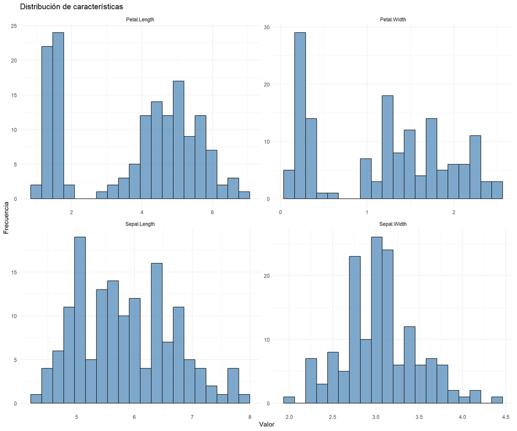

```r
# Histogramas de todas las variables
iris_df %>%
  pivot_longer(cols = -Species, names_to = "variable", values_to = "valor") %>%
  ggplot(aes(x = valor)) +
  geom_histogram(bins = 20, fill = "steelblue", color = "black", alpha = 0.7) +
  facet_wrap(~ variable, scales = "free", ncol = 2) +
  labs(
    title = "Distribución de características",
    x = "Valor",
    y = "Frecuencia"
  ) +
  theme_minimal()
```

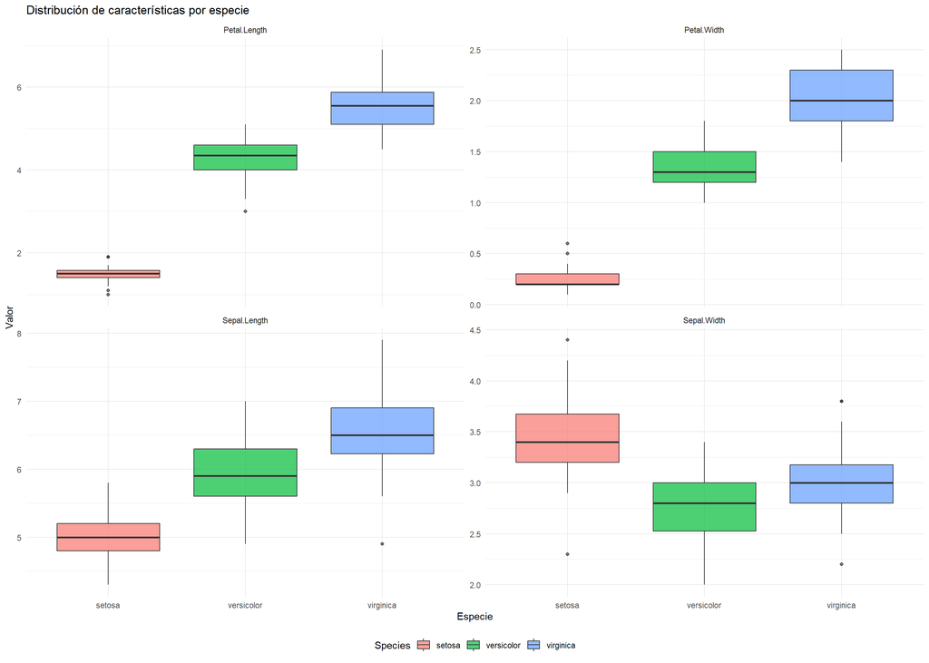

```r
# Boxplots por especie
iris_df %>%
  pivot_longer(cols = -Species, names_to = "variable", values_to = "valor") %>%
  ggplot(aes(x = Species, y = valor, fill = Species)) +
  geom_boxplot(alpha = 0.7) +
  facet_wrap(~ variable, scales = "free_y", ncol = 2) +
  labs(
    title = "Distribución de características por especie",
    x = "Especie",
    y = "Valor"
  ) +
  theme_minimal() +
  theme(legend.position = "bottom")
```

### Análisis bivariado

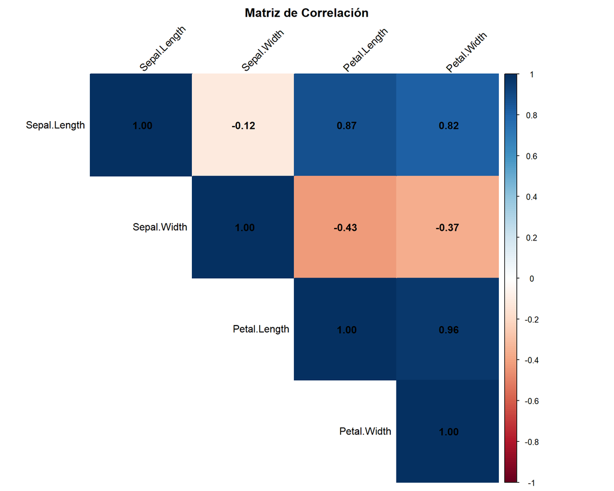

```r
# Matriz de correlación
correlation_matrix <- iris_df %>%
  select(where(is.numeric)) %>%
  cor()

corrplot(
  correlation_matrix,
  method = "color",
  type = "upper",
  addCoef.col = "black",
  tl.col = "black",
  tl.srt = 45,
  title = "Matriz de Correlación",
  mar = c(0, 0, 2, 0)
)
```

```r
cat("\nObservaciones:\n")
```

```
Observaciones:
```

```r
cat("- Petal.Length y Petal.Width tienen alta correlación (0.96)\n")
```

```
- Petal.Length y Petal.Width tienen alta correlación (0.96)
```

```r
cat("- Sepal.Length también correlaciona fuerte con Petal.Length y Petal.Width\n")
```

```
- Sepal.Length también correlaciona fuerte con Petal.Length y Petal.Width
```

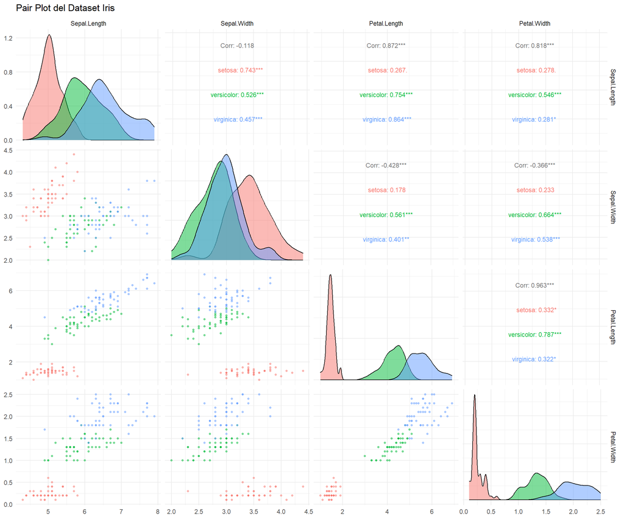

```r
# Pair plot
ggpairs(
  iris_df,
  columns = 1:4,
  mapping = aes(color = Species, alpha = 0.6),
  upper = list(continuous = wrap("cor", size = 3)),
  lower = list(continuous = wrap("points", alpha = 0.5, size = 1)),
  diag = list(continuous = wrap("densityDiag", alpha = 0.5)),
  title = "Pair Plot del Dataset Iris"
) +
  theme_minimal()
```

```r
cat("\nObservaciones del pair plot:\n")
```

```
Observaciones del pair plot:
```

```r
cat("- Setosa se separa claramente del resto\n")
```

```
- Setosa se separa claramente del resto
```

```r
cat("- Versicolor y virginica tienen cierto solapamiento\n")
```

```
- Versicolor y virginica tienen cierto solapamiento
```

```r
cat("- Petal.Length y Petal.Width son las más discriminativas\n")
```

```
- Petal.Length y Petal.Width son las más discriminativas
```

### Detección de outliers

```r
# Función para detectar outliers usando IQR
detectar_outliers_iqr <- function(data, column) {
  Q1 <- quantile(data[[column]], 0.25)
  Q3 <- quantile(data[[column]], 0.75)
  IQR_val <- Q3 - Q1
  lower_bound <- Q1 - 1.5 * IQR_val
  upper_bound <- Q3 + 1.5 * IQR_val

  outliers <- data %>%
    filter(.data[[column]] < lower_bound | .data[[column]] > upper_bound)

  return(outliers)
}

# Detectar outliers para cada variable numérica
cat("Detección de outliers por característica:\n\n")
```

```
Detección de outliers por característica:
```

```r
numeric_cols <- names(iris_df)[sapply(iris_df, is.numeric)]

for (col in numeric_cols) {
  outliers <- detectar_outliers_iqr(iris_df, col)
  cat(col, ":", nrow(outliers), "outliers detectados\n")
}
```

```
Sepal.Length : 0 outliers detectados
Sepal.Width : 4 outliers detectados
Petal.Length : 0 outliers detectados
Petal.Width : 0 outliers detectados
```

```r
cat("\nNota: Los outliers detectados no son necesariamente errores,\n")
```

```
Nota: Los outliers detectados no son necesariamente errores,
```

```r
cat("pueden ser variabilidad natural de los datos.\n")
```

```
pueden ser variabilidad natural de los datos.
```

## Paso 5: Modelado

Vamos a construir un modelo simple de clasificación para predecir la especie.

```r
# Dividir en train y test (80-20)
trainIndex <- createDataPartition(
  iris_df$Species,
  p = 0.8,
  list = FALSE,
  times = 1
)

train_data <- iris_df[trainIndex, ]
test_data <- iris_df[-trainIndex, ]

cat("Tamaño del conjunto de entrenamiento:", nrow(train_data), "ejemplos\n")
```

```
Tamaño del conjunto de entrenamiento: 120 ejemplos
```

```r
cat("Tamaño del conjunto de prueba:", nrow(test_data), "ejemplos\n")
```

```
Tamaño del conjunto de prueba: 30 ejemplos
```

```r
# Entrenar un árbol de decisión
modelo <- rpart(
  Species ~ .,
  data = train_data,
  method = "class",
  control = rpart.control(maxdepth = 3)
)

cat("Modelo entrenado exitosamente\n")
```

```
Modelo entrenado exitosamente
```

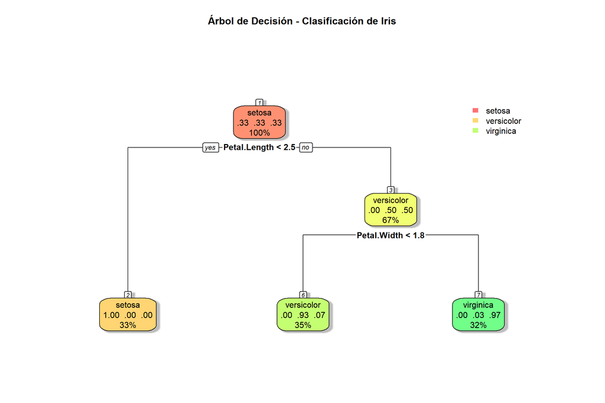

```r
# Visualizar el árbol de decisión
rpart.plot(
  modelo,
  main = "Árbol de Decisión - Clasificación de Iris",
  extra = 104,
  box.palette = "RdYlGn",
  shadow.col = "gray",
  nn = TRUE
)
```

## Paso 6: Evaluación del Modelo

```r
# Hacer predicciones
pred_train <- predict(modelo, train_data, type = "class")
pred_test <- predict(modelo, test_data, type = "class")

# Calcular accuracy
acc_train <- mean(pred_train == train_data$Species)
acc_test <- mean(pred_test == test_data$Species)

cat("Accuracy en entrenamiento:", sprintf("%.2f%%", acc_train * 100), "\n")
```

```
Accuracy en entrenamiento: 96.67%
```

```r
cat("Accuracy en prueba:", sprintf("%.2f%%", acc_test * 100), "\n")
```

```
Accuracy en prueba: 93.33%
```

```r
# Matriz de confusión
cm <- confusionMatrix(pred_test, test_data$Species)
print(cm)
```

```
Confusion Matrix and Statistics

            Reference
Prediction   setosa versicolor virginica
  setosa         10          0         0
  versicolor      0         10         2
  virginica       0          0         8

Overall Statistics

               Accuracy : 0.9333
                 95% CI : (0.7793, 0.9918)
    No Information Rate : 0.3333
    P-Value [Acc > NIR] : 8.747e-12

                  Kappa : 0.9

 Mcnemar's Test P-Value : NA

Statistics by Class:

                     Class: setosa Class: versicolor Class: virginica
Sensitivity                 1.0000            1.0000           0.8000
Specificity                 1.0000            0.9000           1.0000
Pos Pred Value              1.0000            0.8333           1.0000
Neg Pred Value              1.0000            1.0000           0.9091
Prevalence                  0.3333            0.3333           0.3333
Detection Rate              0.3333            0.3333           0.2667
Detection Prevalence        0.3333            0.4000           0.2667
Balanced Accuracy           1.0000            0.9500           0.9000
```

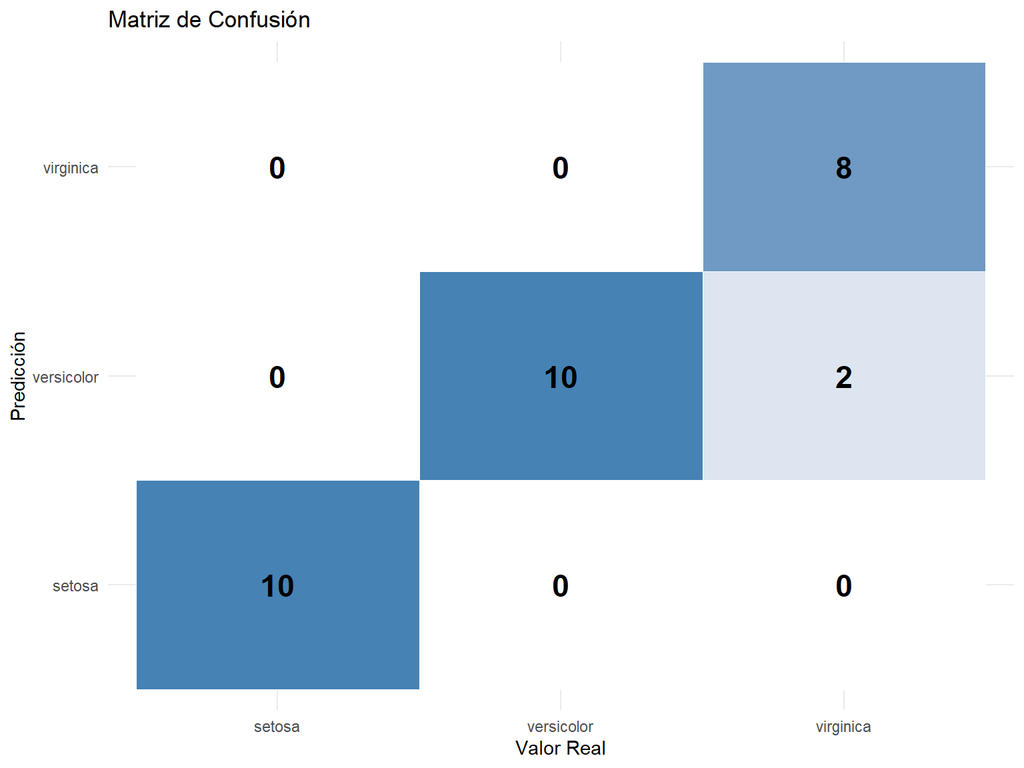

```r
# Visualizar matriz de confusión
cm_table <- as.data.frame(cm$table)

ggplot(cm_table, aes(x = Reference, y = Prediction, fill = Freq)) +
  geom_tile(color = "white") +
  geom_text(aes(label = Freq), size = 6, fontface = "bold") +
  scale_fill_gradient(low = "white", high = "steelblue") +
  labs(
    title = "Matriz de Confusión",
    x = "Valor Real",
    y = "Predicción"
  ) +
  theme_minimal() +
  theme(legend.position = "none")
```

```r
# Importancia de variables
importancia <- as.data.frame(modelo$variable.importance)
importancia$Variable <- rownames(importancia)
names(importancia)[1] <- "Importancia"
importancia <- importancia %>%
  arrange(desc(Importancia))

print("Importancia de características:")
```

```
[1] "Importancia de características:"
```

```r
print(importancia)
```

```
             Importancia     Variable
Petal.Width     72.48120  Petal.Width
Petal.Length    66.49782 Petal.Length
Sepal.Length    45.38583 Sepal.Length
Sepal.Width     32.11199  Sepal.Width
```

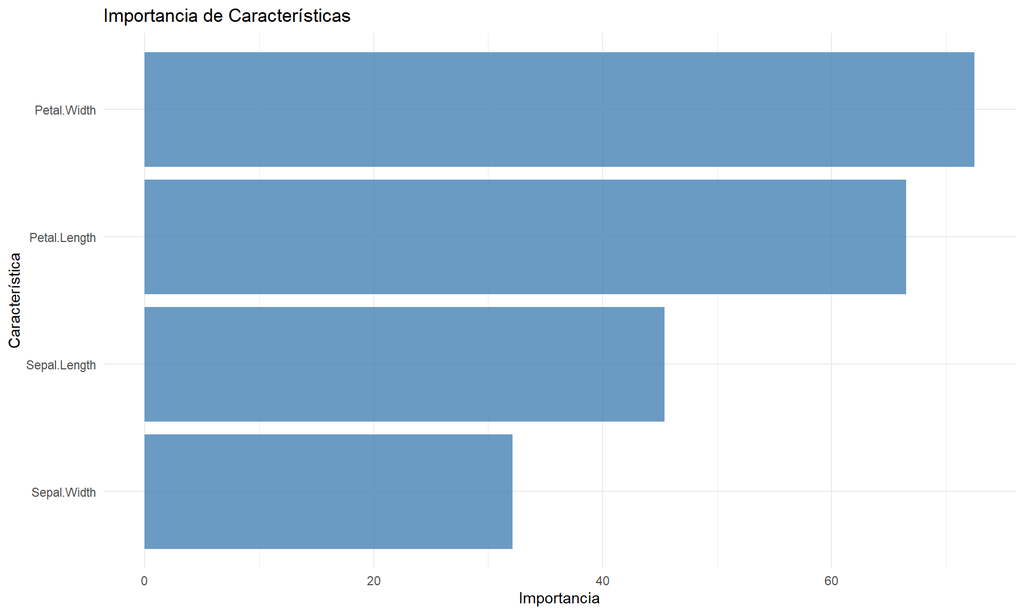

```r
# Visualizar importancia
ggplot(importancia, aes(x = reorder(Variable, Importancia), y = Importancia)) +
  geom_bar(stat = "identity", fill = "steelblue", alpha = 0.8) +
  coord_flip() +
  labs(
    title = "Importancia de Características",
    x = "Característica",
    y = "Importancia"
  ) +
  theme_minimal()
```

## Paso 7: Predicción con nuevos datos

```r
# Crear un nuevo ejemplo (valores inventados)
nueva_flor <- data.frame(
  Sepal.Length = 5.1,
  Sepal.Width = 3.5,
  Petal.Length = 1.4,
  Petal.Width = 0.2
)

# Predecir
prediccion <- predict(modelo, nueva_flor, type = "class")
probabilidades <- predict(modelo, nueva_flor, type = "prob")

cat("Nueva flor:\n")
```

```
Nueva flor:
```

```r
cat("  Sepal.Length:", nueva_flor$Sepal.Length, "cm\n")
```

```
  Sepal.Length: 5.1 cm
```

```r
cat("  Sepal.Width: ", nueva_flor$Sepal.Width, "cm\n")
```

```
  Sepal.Width:  3.5 cm
```

```r
cat("  Petal.Length:", nueva_flor$Petal.Length, "cm\n")
```

```
  Petal.Length: 1.4 cm
```

```r
cat("  Petal.Width: ", nueva_flor$Petal.Width, "cm\n")
```

```
  Petal.Width:  0.2 cm
```

```r
cat("\nEspecie predicha:", as.character(prediccion), "\n")
```

```
Especie predicha: setosa
```

```r
cat("\nProbabilidades:\n")
```

```
Probabilidades:
```

```r
for (i in 1:ncol(probabilidades)) {
  cat(" ", colnames(probabilidades)[i], ":",
      sprintf("%.2f%%", probabilidades[1, i] * 100), "\n")
}
```

```
  setosa : 100.00%
  versicolor : 0.00%
  virginica : 0.00%
```

## Ejercicios Propuestos

1. **Experimentar con otros modelos:**
   - Probar con `randomForest` del paquete `randomForest`
   - Probar con `knn3` de `caret`
   - Comparar los resultados
2. **Análisis de dos especies:**
   - Filtrar el dataset para incluir solo *versicolor* y *virginica*
   - Entrenar un modelo solo con estas dos especies
   - ¿Mejora o empeora el accuracy?
3. **Validación cruzada:**
   - Usar `trainControl` de `caret` para hacer validación cruzada
   - Comparar resultados con el split simple train/test
4. **Feature engineering:**
   - Crear nuevas variables (ej: ratio Petal.Length/Petal.Width)
   - Entrenar modelo con estas nuevas variables
   - ¿Mejora el modelo?
5. **Exportar resultados:**
   - Guardar el modelo entrenado con `saveRDS()`
   - Generar un reporte HTML con este R Markdown
   - Subir a GitHub

## Buenas Prácticas Aplicadas en este Notebook

✓ **Código organizado:** Dividido en chunks con títulos claros

✓ **Semilla fijada:** `set.seed(42)` para reproducibilidad

✓ **Comentarios útiles:** Explican el por qué, no solo el qué

✓ **Visualizaciones claras:** Con títulos, etiquetas y temas consistentes

✓ **Uso de tidyverse:** Código claro y legible con pipes (`%>%`)

✓ **Nombres descriptivos:** Variables con nombres significativos

✓ **Verificaciones:** Chequeo de valores faltantes, duplicados, dimensiones

✓ **Interpretación:** Conclusiones escritas en lenguaje natural

## Próximos Pasos

1. **Renderizar este R Markdown a HTML:**

```r
rmarkdown::render("U0_clases1y2_practica_R.Rmd")
```

2. **Subir este archivo a tu repositorio de GitHub**
3. **Completar los ejercicios propuestos**
4. **Experimentar con el código**
5. **Prepararse para la Unidad 1:** Obtención y preparación de datos

**¡Felicitaciones por completar tu primer análisis de datos en R!**